# DS105-05-02 - ANOVAs - Repeated Measures - in R

## Load Libraries

```r
#install.packages("fastR2")
#install.packages("car")
library("rcompanion")
library("fastR2")
library("car")
```

## Load in Data

```r
breakfast <- read.csv("./assets/breakfast.csv")

  # View data
    head(breakfast)
```

|  | Participant.Code | Treatment.Group | Age..y. | Sex | Height..m. | Baseline.Body.Mass..kg. | Follow.Up.Body.Mass..kg. | Baseline.Lean.Tissue.Mass..kg. | Follow.Up.Lean.Tissue.Mass..kg. | Baseline.Adipose.Tissue.Mass..kg. | Follow.Up.Adipose.Tissue.Mass..kg. | Baseline.BMI..kg.m.2. | Follow.Up.BMI..kg.m.2. | Baseline.FMI..kg.m.2. | Folow.Up.FMI..kg.m.2. | Baseline.Body.Fat.... | Follow.Up.Body.Fat.... | Baseline.Waist.Circumference..cm. | Follow.Up.Waist.Circumference..cm. | Baseline.Waist.Hip.Ratio | Follow.Up.Waist.Hip.Ratio | Baseline.Sagittal.Abdominal.Diameter..cm. | Follow.Up.Sagittal.Abdominal.Diameter..cm. | Baseline.Time.of.Waking..ToD. | Follow.Up.Time.of.Waking..ToD. | Baseline.Time.to.Sleep..ToD. | Follow.Up.Time.to.Sleep..ToD. | Baseline.Sleep.Duration..min. | Follow.Up.Sleep.Duration..min. | … |
| --- | --- | --- | --- | --- | --- | --- | --- | --- | --- | --- | --- | --- | --- | --- | --- | --- | --- | --- | --- | --- | --- | --- | --- | --- | --- | --- | --- | --- | --- | --- |
| 1 | 2 | Fasting | 27 | Female | 1.75 | 71.5 | 71.1 | 51.8 | 52.4 | 15.1 | 15.3 | 23.4 | 23.3 | 5.0 | 5.0 | 21.6 | 21.6 | 71.5 | 73.1 | 0.73 | 0.74 | NA | NA | 8:43 | 7:52 | 22:56 | 22:55 | 588 | 536 | … |
| 2 | 4 | Fasting | 25 | Female | 1.72 | 74.6 | 73.8 | 50.4 | 51.7 | 21.0 | 18.8 | 25.2 | 24.9 | 7.1 | 6.4 | 28.2 | 25.6 | 79.1 | 78.5 | 0.74 | 0.74 | 18.6 | 18.6 | 8:43 | 8:02 | 23:10 | 22:40 | 534 | 525 | … |
| 3 | 11 | Fasting | 44 | Male | 1.64 | 68.0 | 68.1 | 46.7 | 47.0 | 17.9 | 18.0 | 25.3 | 25.4 | 6.7 | 6.7 | 26.6 | 26.5 | 84.0 | 84.8 | 0.98 | 0.96 | 19.5 | 19.8 | 6:35 | 6:24 | 22:32 | 21:45 | 487 | 506 | … |
| 4 | 14 | Fasting | 36 | Female | 1.68 | 57.0 | 57.3 | 41.0 | 41.9 | 13.6 | 12.4 | 20.2 | 20.3 | 4.8 | 4.4 | 23.8 | 21.9 | 70.1 | 71.8 | 0.73 | 0.74 | 18.7 | 16.3 | 6:25 | 6:43 | 21:51 | 21:47 | 499 | 520 | … |
| 5 | 16 | Fasting | 28 | Female | 1.64 | 49.4 | 49.0 | 36.4 | 35.9 | 10.1 | 10.5 | 18.4 | 18.3 | 3.8 | 3.9 | 20.9 | 21.6 | 63.4 | 62.8 | 0.72 | 0.71 | 15.4 | 15.8 | 6:40 | 6:34 | 22:27 | 22:37 | 484 | 464 | … |
| 6 | 19 | Fasting | 38 | Male | 1.74 | 64.3 | 64.0 | 50.0 | 49.3 | 11.1 | 11.7 | 21.2 | 21.1 | 3.7 | 3.8 | 17.4 | 18.4 | 78.1 | 74.7 | 0.85 | 0.80 | 17.6 | 17.1 | 7:10 | 6:57 | 23:47 | 22:45 | 426 | 423 | … |

## Question Setup

**Were there weight changes from baseline to follow?**

## Data Wrangling

### Filter Data

```r
breakfast1 <- breakfast[1:33,]

head(breakfast1)
```

|  | Participant.Code | Treatment.Group | Age..y. | Sex | Height..m. | Baseline.Body.Mass..kg. | Follow.Up.Body.Mass..kg. | Baseline.Lean.Tissue.Mass..kg. | Follow.Up.Lean.Tissue.Mass..kg. | Baseline.Adipose.Tissue.Mass..kg. | Follow.Up.Adipose.Tissue.Mass..kg. | Baseline.BMI..kg.m.2. | Follow.Up.BMI..kg.m.2. | Baseline.FMI..kg.m.2. | Folow.Up.FMI..kg.m.2. | Baseline.Body.Fat.... | Follow.Up.Body.Fat.... | Baseline.Waist.Circumference..cm. | Follow.Up.Waist.Circumference..cm. | Baseline.Waist.Hip.Ratio | Follow.Up.Waist.Hip.Ratio | Baseline.Sagittal.Abdominal.Diameter..cm. | Follow.Up.Sagittal.Abdominal.Diameter..cm. | Baseline.Time.of.Waking..ToD. | Follow.Up.Time.of.Waking..ToD. | Baseline.Time.to.Sleep..ToD. | Follow.Up.Time.to.Sleep..ToD. | Baseline.Sleep.Duration..min. | Follow.Up.Sleep.Duration..min. | … |
| --- | --- | --- | --- | --- | --- | --- | --- | --- | --- | --- | --- | --- | --- | --- | --- | --- | --- | --- | --- | --- | --- | --- | --- | --- | --- | --- | --- | --- | --- | --- |
| 1 | 2 | Fasting | 27 | Female | 1.75 | 71.5 | 71.1 | 51.8 | 52.4 | 15.1 | 15.3 | 23.4 | 23.3 | 5.0 | 5.0 | 21.6 | 21.6 | 71.5 | 73.1 | 0.73 | 0.74 | NA | NA | 8:43 | 7:52 | 22:56 | 22:55 | 588 | 536 | … |
| 2 | 4 | Fasting | 25 | Female | 1.72 | 74.6 | 73.8 | 50.4 | 51.7 | 21.0 | 18.8 | 25.2 | 24.9 | 7.1 | 6.4 | 28.2 | 25.6 | 79.1 | 78.5 | 0.74 | 0.74 | 18.6 | 18.6 | 8:43 | 8:02 | 23:10 | 22:40 | 534 | 525 | … |
| 3 | 11 | Fasting | 44 | Male | 1.64 | 68.0 | 68.1 | 46.7 | 47.0 | 17.9 | 18.0 | 25.3 | 25.4 | 6.7 | 6.7 | 26.6 | 26.5 | 84.0 | 84.8 | 0.98 | 0.96 | 19.5 | 19.8 | 6:35 | 6:24 | 22:32 | 21:45 | 487 | 506 | … |
| 4 | 14 | Fasting | 36 | Female | 1.68 | 57.0 | 57.3 | 41.0 | 41.9 | 13.6 | 12.4 | 20.2 | 20.3 | 4.8 | 4.4 | 23.8 | 21.9 | 70.1 | 71.8 | 0.73 | 0.74 | 18.7 | 16.3 | 6:25 | 6:43 | 21:51 | 21:47 | 499 | 520 | … |
| 5 | 16 | Fasting | 28 | Female | 1.64 | 49.4 | 49.0 | 36.4 | 35.9 | 10.1 | 10.5 | 18.4 | 18.3 | 3.8 | 3.9 | 20.9 | 21.6 | 63.4 | 62.8 | 0.72 | 0.71 | 15.4 | 15.8 | 6:40 | 6:34 | 22:27 | 22:37 | 484 | 464 | … |
| 6 | 19 | Fasting | 38 | Male | 1.74 | 64.3 | 64.0 | 50.0 | 49.3 | 11.1 | 11.7 | 21.2 | 21.1 | 3.7 | 3.8 | 17.4 | 18.4 | 78.1 | 74.7 | 0.85 | 0.80 | 17.6 | 17.1 | 7:10 | 6:57 | 23:47 | 22:45 | 426 | 423 | … |

### Reshape Data

```r
keep = c("Participant.Code", "Treatment.Group", "Age..y.", "Sex", "Height..m.", "Baseline.Body.Mass..kg.", "Follow.Up.Body.Mass..kg.")

breakfast2 <- breakfast1[keep]

head(breakfast2)
```

|  | Participant.Code | Treatment.Group | Age..y. | Sex | Height..m. | Baseline.Body.Mass..kg. | Follow.Up.Body.Mass..kg. |
| --- | --- | --- | --- | --- | --- | --- | --- |
| 1 | 2 | Fasting | 27 | Female | 1.75 | 71.5 | 71.1 |
| 2 | 4 | Fasting | 25 | Female | 1.72 | 74.6 | 73.8 |
| 3 | 11 | Fasting | 44 | Male | 1.64 | 68.0 | 68.1 |
| 4 | 14 | Fasting | 36 | Female | 1.68 | 57.0 | 57.3 |
| 5 | 16 | Fasting | 28 | Female | 1.64 | 49.4 | 49.0 |
| 6 | 19 | Fasting | 38 | Male | 1.74 | 64.3 | 64.0 |

## Baseline Data

```r
breakfast3 <- breakfast2[,1:5]
breakfast3$repdat <- breakfast2$Baseline.Body.Mass..kg.
breakfast3$contrasts <- "T1"
head(breakfast3)
```

|  | Participant.Code | Treatment.Group | Age..y. | Sex | Height..m. | repdat | contrasts |
| --- | --- | --- | --- | --- | --- | --- | --- |
| 1 | 2 | Fasting | 27 | Female | 1.75 | 71.5 | T1 |
| 2 | 4 | Fasting | 25 | Female | 1.72 | 74.6 | T1 |
| 3 | 11 | Fasting | 44 | Male | 1.64 | 68.0 | T1 |
| 4 | 14 | Fasting | 36 | Female | 1.68 | 57.0 | T1 |
| 5 | 16 | Fasting | 28 | Female | 1.64 | 49.4 | T1 |
| 6 | 19 | Fasting | 38 | Male | 1.74 | 64.3 | T1 |

## Follow-up Data

```r
breakfast4 <- breakfast2[,1:5]
breakfast4$repdat <- breakfast2$Follow.Up.Body.Mass..kg.
breakfast4$contrasts <- "T2"
head(breakfast4)
```

|  | Participant.Code | Treatment.Group | Age..y. | Sex | Height..m. | repdat | contrasts |
| --- | --- | --- | --- | --- | --- | --- | --- |
| 1 | 2 | Fasting | 27 | Female | 1.75 | 71.1 | T2 |
| 2 | 4 | Fasting | 25 | Female | 1.72 | 73.8 | T2 |
| 3 | 11 | Fasting | 44 | Male | 1.64 | 68.1 | T2 |
| 4 | 14 | Fasting | 36 | Female | 1.68 | 57.3 | T2 |
| 5 | 16 | Fasting | 28 | Female | 1.64 | 49.0 | T2 |
| 6 | 19 | Fasting | 38 | Male | 1.74 | 64.0 | T2 |

Once you have both of those, then you need to `rbind()` them back together into one whole dataset:

```r
breakfast5 <- rbind(breakfast3, breakfast4)
```

Now you are all prepared to run a repeated measures ANOVA, data shaping wise.

## **Test Assumptions**

### **Assumption: Normality**

You only need to test for the normality of the dependent variable, but you need to do it at both timepoints. So scoot on back to `breakfast2`, which is the dataset you truncated but had not yet reshaped.

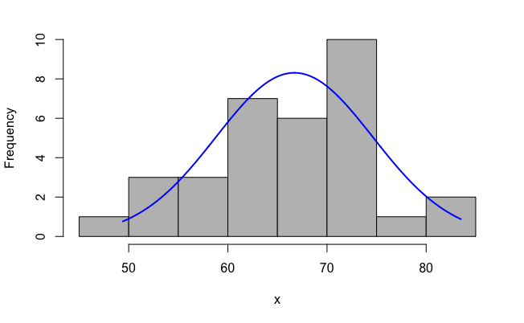

```r
plotNormalHistogram(breakfast2$Baseline.Body.Mass..kg.)
```

Try the follow-up data:

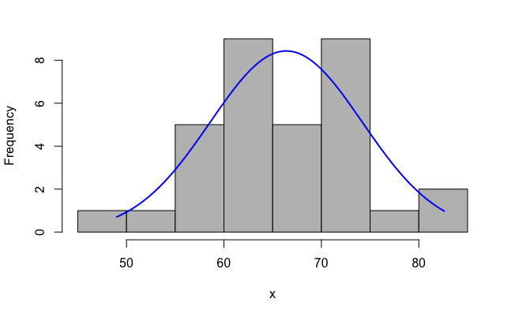

```r
plotNormalHistogram(breakfast2$Follow.Up.Body.Mass..kg.)
```

**Meets assumption of Normality.**

**Assumption: Homogeneity of Variance**

```r
leveneTest(repdat ~ Treatment.Group*contrasts, data=breakfast5)
```

```
Levene's Test for Homogeneity of Variance (center = median)
      Df F value Pr(>F)
group  3  0.0623 0.9795
      62
```

**Meets assumption of Homogeneity of Variance.**  
**`p > .05`**, which means that the data meets the assumption of Homogeneity of Variance.

### Sample Size

A repeated measures ANOVA requires a sample size of at least 20 per independent variable.

```r
str(breakfast5)
```

```
'data.frame':   66 obs. of  7 variables:
 $ Participant.Code: int  2 4 11 14 16 19 20 23 27 34 ...
 $ Treatment.Group : chr  "Fasting" "Fasting" "Fasting" "Fasting" ...
 $ Age..y.         : int  27 25 44 36 28 38 48 54 27 22 ...
 $ Sex             : chr  "Female" "Female" "Male" "Female" ...
 $ Height..m.      : num  1.75 1.72 1.64 1.68 1.64 1.74 1.78 1.75 1.63 1.66 ...
 $ repdat          : num  71.5 74.6 68 57 49.4 64.3 66.5 73.5 59 67.1 ...
 $ contrasts       : chr  "T1" "T1" "T1" "T1" ...
```

**Meets assumption of adequate sample size.**

### Sphericity

The only way to test for sphericity in R is to take a multivariate approach and make it work for an ANOVA. At this time, that is a bit too complex, but it may be covered later.

## **Analysis**

You will continue to use the `aov()` function, but add some additional arguments to it to make it repeated measures.

```r
RManova <- aov(repdat~contrasts+Error(Participant.Code), breakfast5)
summary(RManova)
```

```
Error: Participant.Code
          Df Sum Sq Mean Sq F value Pr(>F)
Residuals  1  105.3   105.3

Error: Within
          Df Sum Sq Mean Sq F value Pr(>F)
contrasts  1      2    1.64   0.027  0.871
Residuals 63   3854   61.17
```

# Conclusion:

*`p`* **`> .5`**, which indicates there is *not a significant effect* of time on the participants’ body mass.